# Question

Let function $f$ be defined by the rational expression below.

$$f(x)~=~\frac{{-7}x+{2}}{x-{8}}$$

Its inverse function can be expressed in the following form. Please find the values of the three parameters: $a$, $b$, and $c$.

$$f^{-1}(x)~=~\frac{ax+b}{x+c}$$

- $a=$ ##ANSWER1##
- $b=$ ##ANSWER2##
- $c=$ ##ANSWER3##

## Answerlist

- -9
- -8
- -7
- -6
- -5
- -4
- -3
- -2
- -1
- 0
- 1
- 2
- 3
- 4
- 5
- 6
- 7
- 8
- 9
- -9
- -8
- -7
- -6
- -5
- -4
- -3
- -2
- -1
- 0
- 1
- 2
- 3
- 4
- 5
- 6
- 7
- 8
- 9
- -9
- -8
- -7
- -6
- -5
- -4
- -3
- -2
- -1
- 0
- 1
- 2
- 3
- 4
- 5
- 6
- 7
- 8
- 9

# Solution

Start by getting rid of function notation.

$$y~=~\frac{{-7}x+{2}}{x-{8}}$$

To find the **inverse**, swap the $x$ and $y$.

$$x~=~\frac{{-7}y+{2}}{y-{8}}$$

Our goal is to get $y$ by itself (solve for $y$). Multiply both sides by $y-{8}$.

$$x\cdot(y-8)~=~-7y+2$$

Distribute $x$ to get rid of parentheses.

$$xy-8x~=~-7y+2$$

Notice all terms are either linear in $y$ or independent of $y$. This means we can gather all the terms with $y$ onto the left side and all the terms without $y$ onto the right side. We do this by subtracting $-8x$ from both sides and subtracting $-7y$ from both sides.

$$xy+7y~=~8x+2$$

Factor out the $y$ from both terms on the left side of the equation.

$$y\cdot(x+7)~=~8x+2$$

Divide both sides by $x+7$.

$$y~=~\frac{8x+2}{x+7}$$

Return to function notation, using $f^{-1}$ for inverse.

$$f^{-1}(x)~=~\frac{8x+2}{x+7}$$

So,

$$a=8$$
$$b=2$$
$$c=7$$

To visually confirm that the two are indeed inverses, graph both to see they are reflections over the $y=x$ line.

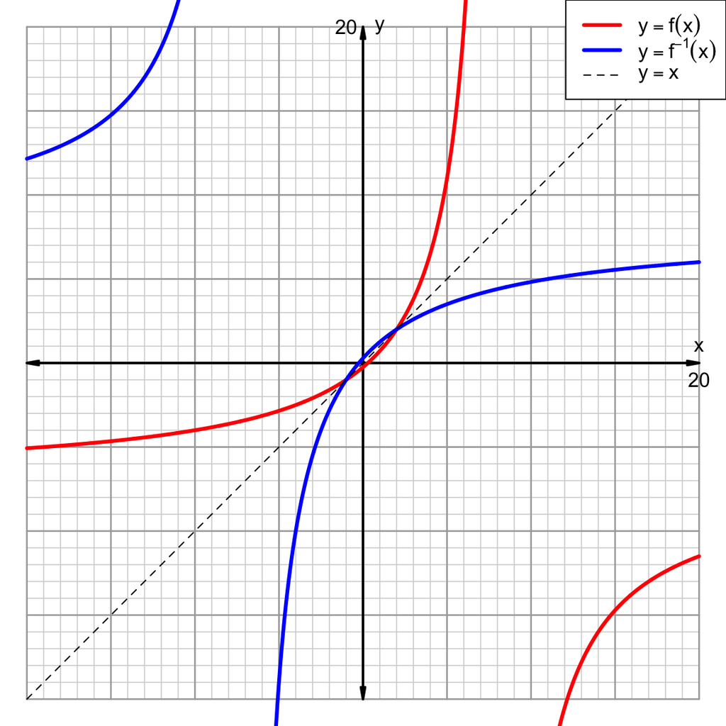

# Meta-information

extype: cloze exclozetype: schoice|schoice|schoice exsolution: 0000000000000000010|0000000000010000000|0000000000000000100 exname: inverse_rational